# Cyclistic: Bike share analysis

Susannah Moses

2024-01-09

## Cyclistic: Bike-Share analysis using R

### Background

In 2016, Cyclistic launched a successful bike-share offering. Since then, the program has grown to a fleet of 5,824 bicycles that are geo-tracked and locked into a network of 692 stations across Chicago. The bikes can be unlocked from one station and returned to any other station in the system anytime.

Until now, Cyclistic’s marketing strategy relied on building general awareness and appealing to broad consumer segments. One approach that helped make these things possible was the flexibility of its pricing plans: single-ride passes, full-day passes, and annual memberships. Customers who purchase single-ride or full-day passes are referred to as **casual** riders. Customers who purchase annual memberships are Cyclistic **members**.

Cyclistic’s finance analysts have concluded that annual members are much more profitable than casual riders. Although the pricing flexibility helps Cyclistic attract more customers, Lily Moreno, the director of marketing believes that maximizing the number of annual members will be key to future growth. Rather than creating a marketing campaign that targets all-new customers, Moreno believes there is a very good chance to convert casual riders into members. She notes that casual riders are already aware of the Cyclistic program and have chosen Cyclistic for their mobility needs.

Moreno has set a clear goal: Design marketing strategies aimed at converting casual riders into annual members. In order to do that, however, the marketing analyst team needs to better understand how annual members and casual riders differ, why casual riders would buy a membership, and how digital media could affect their marketing tactics.

**My role:** I am a junior data analyst, working in the marketing analyst team at Cyclistic.

**Overall goal for the entire team:** Design marketing strategies aimed at converting casual riders into annual members.

I have been asked to do a specific business task (mentioned below).

The business task is done by following through all the steps of data analysis.

1.Ask 2.Prepare 3.Process 4.Analyze 5.Share 6.Act

### 1. Ask

**Business task:** *How do annual members and casual riders use Cyclistic bike differently?*

### 2. Prepare

**Data Source**: The data used for solving the above business task is downloaded from [the Cyclistic trip data.](https://divvy-tripdata.s3.amazonaws.com/index.html). I used data from the period Nov 2022 - Oct 2023.

I downloaded the data and stored it locally in my computer. It is organized by month and year and stored as zip files.

**Data credibility** The data is reliable and original. It is comprehensive and has the required information to solve the business problem It is current and cited from this site [Click here](https://divvy-tripdata.s3.amazonaws.com/index.html)

**Data License**

The data has been made available by *Motivate International Inc* under this [license](https://divvybikes.com/data-license-agreement)

Data-privacy issues prohibits me from using riders’ personally identifiable information and I won’t be able to connect pass purchases to credit card numbers to determine if casual riders live in the Cyclistic service area or if they have purchased multiple single passes.

### 3.Process

I have used the R programming language for processing and analyzing data and making it ready for creating visualizations.

#### 3.1 Loading the required packages

```r
library(tidyverse) #helps wrangle data
library(janitor) #helps with data cleaning
```

#### 3.2 Setting up the working directory and loading data

```r
setwd("~/Data analysis/Module 8/Case study_cyclistic/CSV files")
Nov_22 <- read_csv("202211-divvy-tripdata.csv")
Dec_22 <- read_csv("202212-divvy-tripdata.csv")
Jan_23 <- read_csv("202301-divvy-tripdata.csv")
Feb_23 <- read_csv("202302-divvy-tripdata.csv")
Mar_23 <- read_csv("202303-divvy-tripdata.csv")
Apr_23 <- read_csv("202304-divvy-tripdata.csv")
May_23 <- read_csv("202305-divvy-tripdata.csv")
Jun_23 <- read_csv("202306-divvy-tripdata.csv")
Jul_23 <- read_csv("202307-divvy-tripdata.csv")
Aug_23 <- read_csv("202308-divvy-tripdata.csv")
Sep_23 <- read_csv("202309-divvy-tripdata.csv")
Oct_23 <- read_csv("202310-divvy-tripdata.csv")
```

*I’m attaching a picture of one of these csv files to give an idea of how the data looks*

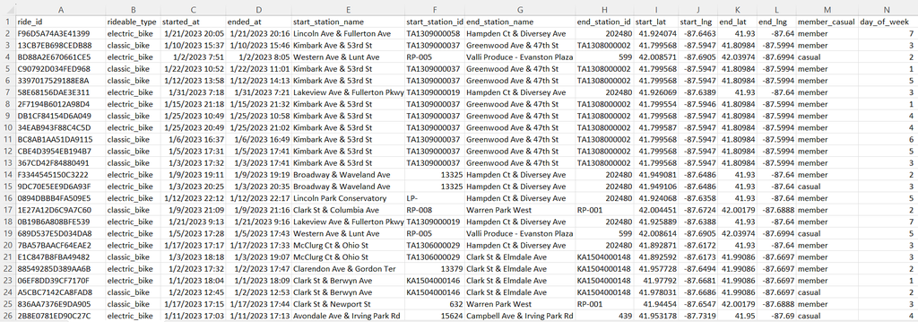

```r
knitr::include_graphics("Sample_csv.png")
```

#### 3.3 Getting an overview of each of the dataframe

```r
summary(Nov_22)
```

```
##    ride_id          rideable_type       started_at          ended_at
##  Length:337735      Length:337735      Length:337735      Length:337735
##  Class :character   Class :character   Class :character   Class :character
##  Mode  :character   Mode  :character   Mode  :character   Mode  :character
##
##
##
##
##  start_station_name start_station_id   end_station_name   end_station_id
##  Length:337735      Length:337735      Length:337735      Length:337735
##  Class :character   Class :character   Class :character   Class :character
##  Mode  :character   Mode  :character   Mode  :character   Mode  :character
##
##
##
##
##    start_lat       start_lng         end_lat         end_lng
##  Min.   :41.65   Min.   :-87.84   Min.   : 0.00   Min.   :-87.84
##  1st Qu.:41.88   1st Qu.:-87.66   1st Qu.:41.88   1st Qu.:-87.66
##  Median :41.90   Median :-87.64   Median :41.90   Median :-87.65
##  Mean   :41.90   Mean   :-87.65   Mean   :41.90   Mean   :-87.65
##  3rd Qu.:41.93   3rd Qu.:-87.63   3rd Qu.:41.93   3rd Qu.:-87.63
##  Max.   :42.07   Max.   :-87.52   Max.   :42.08   Max.   :  0.00
##                                   NA's   :230     NA's   :230
##  member_casual       day_of_week
##  Length:337735      Min.   :1.000
##  Class :character   1st Qu.:3.000
##  Mode  :character   Median :4.000
##                     Mean   :3.987
##                     3rd Qu.:5.000
##                     Max.   :7.000
##
```

```r
summary(Dec_22)
```

```
##    ride_id          rideable_type       started_at          ended_at
##  Length:181806      Length:181806      Length:181806      Length:181806
##  Class :character   Class :character   Class :character   Class :character
##  Mode  :character   Mode  :character   Mode  :character   Mode  :character
##
##
##
##
##  start_station_name start_station_id   end_station_name   end_station_id
##  Length:181806      Length:181806      Length:181806      Length:181806
##  Class :character   Class :character   Class :character   Class :character
##  Mode  :character   Mode  :character   Mode  :character   Mode  :character
##
##
##
##
##    start_lat       start_lng         end_lat         end_lng
##  Min.   :41.65   Min.   :-87.83   Min.   :41.64   Min.   :-87.84
##  1st Qu.:41.88   1st Qu.:-87.66   1st Qu.:41.88   1st Qu.:-87.66
##  Median :41.90   Median :-87.65   Median :41.90   Median :-87.65
##  Mean   :41.90   Mean   :-87.65   Mean   :41.90   Mean   :-87.65
##  3rd Qu.:41.93   3rd Qu.:-87.63   3rd Qu.:41.93   3rd Qu.:-87.63
##  Max.   :42.07   Max.   :-87.53   Max.   :42.07   Max.   :-87.52
##                                   NA's   :128     NA's   :128
##  member_casual       day_of_week
##  Length:181806      Min.   :1.00
##  Class :character   1st Qu.:3.00
##  Mode  :character   Median :4.00
##                     Mean   :4.19
##                     3rd Qu.:6.00
##                     Max.   :7.00
##
```

```r
summary(Jan_23)
```

```
##    ride_id          rideable_type       started_at          ended_at
##  Length:190301      Length:190301      Length:190301      Length:190301
##  Class :character   Class :character   Class :character   Class :character
##  Mode  :character   Mode  :character   Mode  :character   Mode  :character
##
##
##
##
##  start_station_name start_station_id   end_station_name   end_station_id
##  Length:190301      Length:190301      Length:190301      Length:190301
##  Class :character   Class :character   Class :character   Class :character
##  Mode  :character   Mode  :character   Mode  :character   Mode  :character
##
##
##
##
##    start_lat       start_lng         end_lat         end_lng
##  Min.   :41.65   Min.   :-87.83   Min.   :41.65   Min.   :-87.84
##  1st Qu.:41.88   1st Qu.:-87.66   1st Qu.:41.88   1st Qu.:-87.66
##  Median :41.89   Median :-87.64   Median :41.89   Median :-87.64
##  Mean   :41.90   Mean   :-87.65   Mean   :41.90   Mean   :-87.65
##  3rd Qu.:41.93   3rd Qu.:-87.63   3rd Qu.:41.93   3rd Qu.:-87.63
##  Max.   :42.07   Max.   :-87.53   Max.   :42.08   Max.   :-87.53
##                                   NA's   :127     NA's   :127
##  member_casual       day_of_week
##  Length:190301      Min.   :1.00
##  Class :character   1st Qu.:2.00
##  Mode  :character   Median :4.00
##                     Mean   :3.88
##                     3rd Qu.:5.00
##                     Max.   :7.00
##
```

```r
summary(Feb_23)
```

```
##    ride_id          rideable_type       started_at          ended_at
##  Length:190445      Length:190445      Length:190445      Length:190445
##  Class :character   Class :character   Class :character   Class :character
##  Mode  :character   Mode  :character   Mode  :character   Mode  :character
##
##
##
##
##  start_station_name start_station_id   end_station_name   end_station_id
##  Length:190445      Length:190445      Length:190445      Length:190445
##  Class :character   Class :character   Class :character   Class :character
##  Mode  :character   Mode  :character   Mode  :character   Mode  :character
##
##
##
##
##    start_lat       start_lng         end_lat         end_lng
##  Min.   :41.65   Min.   :-87.84   Min.   :41.65   Min.   :-87.90
##  1st Qu.:41.88   1st Qu.:-87.66   1st Qu.:41.88   1st Qu.:-87.66
##  Median :41.89   Median :-87.64   Median :41.89   Median :-87.64
##  Mean   :41.90   Mean   :-87.65   Mean   :41.90   Mean   :-87.65
##  3rd Qu.:41.93   3rd Qu.:-87.63   3rd Qu.:41.93   3rd Qu.:-87.63
##  Max.   :42.07   Max.   :-87.53   Max.   :42.07   Max.   :-87.53
##                                   NA's   :116     NA's   :116
##  member_casual       day_of_week
##  Length:190445      Min.   :1.000
##  Class :character   1st Qu.:2.000
##  Mode  :character   Median :3.000
##                     Mean   :3.733
##                     3rd Qu.:5.000
##                     Max.   :7.000
##
```

```r
summary(Mar_23)
```

```
##    ride_id          rideable_type       started_at          ended_at
##  Length:258678      Length:258678      Length:258678      Length:258678
##  Class :character   Class :character   Class :character   Class :character
##  Mode  :character   Mode  :character   Mode  :character   Mode  :character
##
##
##
##
##  start_station_name start_station_id   end_station_name   end_station_id
##  Length:258678      Length:258678      Length:258678      Length:258678
##  Class :character   Class :character   Class :character   Class :character
##  Mode  :character   Mode  :character   Mode  :character   Mode  :character
##
##
##
##
##    start_lat       start_lng         end_lat         end_lng
##  Min.   :41.65   Min.   :-87.83   Min.   :41.63   Min.   :-87.85
##  1st Qu.:41.88   1st Qu.:-87.66   1st Qu.:41.88   1st Qu.:-87.66
##  Median :41.89   Median :-87.64   Median :41.89   Median :-87.64
##  Mean   :41.90   Mean   :-87.65   Mean   :41.90   Mean   :-87.65
##  3rd Qu.:41.93   3rd Qu.:-87.63   3rd Qu.:41.93   3rd Qu.:-87.63
##  Max.   :42.07   Max.   :-87.53   Max.   :42.08   Max.   :-87.52
##                                   NA's   :183     NA's   :183
##  member_casual       day_of_week
##  Length:258678      Min.   :1.000
##  Class :character   1st Qu.:3.000
##  Mode  :character   Median :4.000
##                     Mean   :4.071
##                     3rd Qu.:5.000
##                     Max.   :7.000
##
```

```r
summary(Apr_23)
```

```
##    ride_id          rideable_type       started_at          ended_at
##  Length:426590      Length:426590      Length:426590      Length:426590
##  Class :character   Class :character   Class :character   Class :character
##  Mode  :character   Mode  :character   Mode  :character   Mode  :character
##
##
##
##
##  start_station_name start_station_id   end_station_name   end_station_id
##  Length:426590      Length:426590      Length:426590      Length:426590
##  Class :character   Class :character   Class :character   Class :character
##  Mode  :character   Mode  :character   Mode  :character   Mode  :character
##
##
##
##
##    start_lat       start_lng         end_lat         end_lng
##  Min.   :41.65   Min.   :-87.83   Min.   :41.65   Min.   :-88.11
##  1st Qu.:41.88   1st Qu.:-87.66   1st Qu.:41.88   1st Qu.:-87.66
##  Median :41.90   Median :-87.64   Median :41.90   Median :-87.64
##  Mean   :41.90   Mean   :-87.65   Mean   :41.90   Mean   :-87.65
##  3rd Qu.:41.93   3rd Qu.:-87.63   3rd Qu.:41.93   3rd Qu.:-87.63
##  Max.   :42.07   Max.   :-87.52   Max.   :42.08   Max.   :-87.53
##                                   NA's   :435     NA's   :435
##  member_casual       day_of_week
##  Length:426590      Min.   :1.000
##  Class :character   1st Qu.:3.000
##  Mode  :character   Median :5.000
##                     Mean   :4.321
##                     3rd Qu.:6.000
##                     Max.   :7.000
##
```

```r
summary(May_23)
```

```
##    ride_id          rideable_type       started_at          ended_at
##  Length:604827      Length:604827      Length:604827      Length:604827
##  Class :character   Class :character   Class :character   Class :character
##  Mode  :character   Mode  :character   Mode  :character   Mode  :character
##
##
##
##
##  start_station_name start_station_id   end_station_name   end_station_id
##  Length:604827      Length:604827      Length:604827      Length:604827
##  Class :character   Class :character   Class :character   Class :character
##  Mode  :character   Mode  :character   Mode  :character   Mode  :character
##
##
##
##
##    start_lat       start_lng         end_lat         end_lng
##  Min.   :41.65   Min.   :-87.87   Min.   :41.62   Min.   :-87.91
##  1st Qu.:41.88   1st Qu.:-87.66   1st Qu.:41.88   1st Qu.:-87.66
##  Median :41.90   Median :-87.64   Median :41.90   Median :-87.64
##  Mean   :41.90   Mean   :-87.65   Mean   :41.90   Mean   :-87.65
##  3rd Qu.:41.93   3rd Qu.:-87.63   3rd Qu.:41.93   3rd Qu.:-87.63
##  Max.   :42.07   Max.   :-87.53   Max.   :42.11   Max.   :-87.53
##                                   NA's   :710     NA's   :710
##  member_casual       day_of_week
##  Length:604827      Min.   :1.000
##  Class :character   1st Qu.:2.000
##  Mode  :character   Median :4.000
##                     Mean   :3.964
##                     3rd Qu.:6.000
##                     Max.   :7.000
##
```

```r
summary(Jun_23)
```

```
##    ride_id          rideable_type       started_at          ended_at
##  Length:719618      Length:719618      Length:719618      Length:719618
##  Class :character   Class :character   Class :character   Class :character
##  Mode  :character   Mode  :character   Mode  :character   Mode  :character
##
##
##
##
##  start_station_name start_station_id   end_station_name   end_station_id
##  Length:719618      Length:719618      Length:719618      Length:719618
##  Class :character   Class :character   Class :character   Class :character
##  Mode  :character   Mode  :character   Mode  :character   Mode  :character
##
##
##
##
##    start_lat       start_lng         end_lat         end_lng
##  Min.   :41.64   Min.   :-87.87   Min.   : 0.00   Min.   :-88.16
##  1st Qu.:41.88   1st Qu.:-87.66   1st Qu.:41.88   1st Qu.:-87.66
##  Median :41.90   Median :-87.64   Median :41.90   Median :-87.64
##  Mean   :41.91   Mean   :-87.65   Mean   :41.91   Mean   :-87.65
##  3rd Qu.:41.93   3rd Qu.:-87.63   3rd Qu.:41.93   3rd Qu.:-87.63
##  Max.   :42.07   Max.   :-87.53   Max.   :42.11   Max.   :  0.00
##                                   NA's   :889     NA's   :889
##  member_casual       day_of_week
##  Length:719618      Min.   :1.000
##  Class :character   1st Qu.:3.000
##  Mode  :character   Median :5.000
##                     Mean   :4.378
##                     3rd Qu.:6.000
##                     Max.   :7.000
##
```

```r
summary(Jul_23)
```

```
##    ride_id          rideable_type       started_at          ended_at
##  Length:767650      Length:767650      Length:767650      Length:767650
##  Class :character   Class :character   Class :character   Class :character
##  Mode  :character   Mode  :character   Mode  :character   Mode  :character
##
##
##
##
##  start_station_name start_station_id   end_station_name   end_station_id
##  Length:767650      Length:767650      Length:767650      Length:767650
##  Class :character   Class :character   Class :character   Class :character
##  Mode  :character   Mode  :character   Mode  :character   Mode  :character
##
##
##
##
##    start_lat       start_lng         end_lat         end_lng
##  Min.   :41.65   Min.   :-87.92   Min.   :41.61   Min.   :-87.92
##  1st Qu.:41.88   1st Qu.:-87.66   1st Qu.:41.88   1st Qu.:-87.66
##  Median :41.90   Median :-87.64   Median :41.90   Median :-87.64
##  Mean   :41.91   Mean   :-87.65   Mean   :41.91   Mean   :-87.65
##  3rd Qu.:41.93   3rd Qu.:-87.63   3rd Qu.:41.93   3rd Qu.:-87.63
##  Max.   :42.07   Max.   :-87.53   Max.   :42.18   Max.   :-87.51
##                                   NA's   :1254    NA's   :1254
##  member_casual       day_of_week
##  Length:767650      Min.   :1.000
##  Class :character   1st Qu.:2.000
##  Mode  :character   Median :4.000
##                     Mean   :4.032
##                     3rd Qu.:6.000
##                     Max.   :7.000
##
```

```r
summary(Aug_23)
```

```
##    ride_id          rideable_type       started_at          ended_at
##  Length:771693      Length:771693      Length:771693      Length:771693
##  Class :character   Class :character   Class :character   Class :character
##  Mode  :character   Mode  :character   Mode  :character   Mode  :character
##
##
##
##
##  start_station_name start_station_id   end_station_name   end_station_id
##  Length:771693      Length:771693      Length:771693      Length:771693
##  Class :character   Class :character   Class :character   Class :character
##  Mode  :character   Mode  :character   Mode  :character   Mode  :character
##
##
##
##
##    start_lat       start_lng         end_lat         end_lng
##  Min.   :41.63   Min.   :-87.86   Min.   : 0.00   Min.   :-87.98
##  1st Qu.:41.88   1st Qu.:-87.66   1st Qu.:41.88   1st Qu.:-87.66
##  Median :41.90   Median :-87.64   Median :41.90   Median :-87.64
##  Mean   :41.91   Mean   :-87.65   Mean   :41.91   Mean   :-87.65
##  3rd Qu.:41.93   3rd Qu.:-87.63   3rd Qu.:41.93   3rd Qu.:-87.63
##  Max.   :42.07   Max.   :-87.46   Max.   :42.10   Max.   :  0.00
##                                   NA's   :1257    NA's   :1257
##  member_casual       day_of_week
##  Length:771693      Min.   :1.000
##  Class :character   1st Qu.:3.000
##  Mode  :character   Median :4.000
##                     Mean   :4.146
##                     3rd Qu.:6.000
##                     Max.   :7.000
##
```

```r
summary(Sep_23)
```

```
##    ride_id          rideable_type       started_at          ended_at
##  Length:666371      Length:666371      Length:666371      Length:666371
##  Class :character   Class :character   Class :character   Class :character
##  Mode  :character   Mode  :character   Mode  :character   Mode  :character
##
##
##
##
##  start_station_name start_station_id   end_station_name   end_station_id
##  Length:666371      Length:666371      Length:666371      Length:666371
##  Class :character   Class :character   Class :character   Class :character
##  Mode  :character   Mode  :character   Mode  :character   Mode  :character
##
##
##
##
##    start_lat       start_lng         end_lat         end_lng
##  Min.   :41.65   Min.   :-87.94   Min.   :41.62   Min.   :-87.94
##  1st Qu.:41.88   1st Qu.:-87.66   1st Qu.:41.88   1st Qu.:-87.66
##  Median :41.90   Median :-87.64   Median :41.90   Median :-87.65
##  Mean   :41.90   Mean   :-87.65   Mean   :41.90   Mean   :-87.65
##  3rd Qu.:41.93   3rd Qu.:-87.63   3rd Qu.:41.93   3rd Qu.:-87.63
##  Max.   :42.07   Max.   :-87.53   Max.   :42.12   Max.   :-87.49
##                                   NA's   :838     NA's   :838
##  member_casual       day_of_week
##  Length:666371      Min.   :1.000
##  Class :character   1st Qu.:3.000
##  Mode  :character   Median :5.000
##                     Mean   :4.377
##                     3rd Qu.:6.000
##                     Max.   :7.000
##
```

```r
summary(Oct_23)
```

```
##    ride_id          rideable_type       started_at          ended_at
##  Length:537113      Length:537113      Length:537113      Length:537113
##  Class :character   Class :character   Class :character   Class :character
##  Mode  :character   Mode  :character   Mode  :character   Mode  :character
##
##
##
##
##  start_station_name start_station_id   end_station_name   end_station_id
##  Length:537113      Length:537113      Length:537113      Length:537113
##  Class :character   Class :character   Class :character   Class :character
##  Mode  :character   Mode  :character   Mode  :character   Mode  :character
##
##
##
##
##    start_lat       start_lng         end_lat         end_lng
##  Min.   :41.64   Min.   :-87.86   Min.   :41.64   Min.   :-87.99
##  1st Qu.:41.88   1st Qu.:-87.66   1st Qu.:41.88   1st Qu.:-87.66
##  Median :41.90   Median :-87.64   Median :41.90   Median :-87.64
##  Mean   :41.90   Mean   :-87.65   Mean   :41.90   Mean   :-87.65
##  3rd Qu.:41.93   3rd Qu.:-87.63   3rd Qu.:41.93   3rd Qu.:-87.63
##  Max.   :42.07   Max.   :-87.52   Max.   :42.07   Max.   :-87.52
##                                   NA's   :592     NA's   :592
##  member_casual       day_of_week
##  Length:537113      Min.   :1.000
##  Class :character   1st Qu.:2.000
##  Mode  :character   Median :4.000
##                     Mean   :3.745
##                     3rd Qu.:5.000
##                     Max.   :7.000
##
```

#### 3.4 Comparing the columns of each data frame before combining them into one dataframe

This is a crucial step as we need to make sure that the column names of each individual data frames and their data types match. Only then we can combine them together without any issues.This is done using the compare_df_cols() function from the janitor package.

```r
compare_df_cols(Nov_22,Dec_22,Jan_23,Feb_23,Mar_23,Apr_23,May_23,Jun_23,Jul_23,Aug_23,Sep_23,Oct_23, return = 'mismatch')
```

```
##  [1] column_name Nov_22      Dec_22      Jan_23      Feb_23      Mar_23
##  [7] Apr_23      May_23      Jun_23      Jul_23      Aug_23      Sep_23
## [13] Oct_23
## <0 rows> (or 0-length row.names)
```

This shows that all the column names and their data types match.

#### 3.5 Combining individual dataframes into one big data frame

```r
all_rides <- bind_rows(Nov_22,Dec_22,Jan_23,Feb_23,Mar_23,Apr_23,May_23,Jun_23,Jul_23,Aug_23,Sep_23,Oct_23)
```

Now let’s take an initial overall look at our combined data frame

```r
head(all_rides)
```

```
## # A tibble: 6 × 14
##   ride_id  rideable_type started_at ended_at start_station_name start_station_id
##   <chr>    <chr>         <chr>      <chr>    <chr>              <chr>
## 1 BCC66FC… electric_bike 11/10/202… 11/10/2… Canal St & Adams … 13011
## 2 772AB67… classic_bike  11/4/2022… 11/4/20… Canal St & Adams … 13011
## 3 585EAD0… classic_bike  11/21/202… 11/21/2… Indiana Ave & Roo… SL-005
## 4 91C4E7E… classic_bike  11/25/202… 11/25/2… Indiana Ave & Roo… SL-005
## 5 709206A… classic_bike  11/29/202… 11/29/2… Indiana Ave & Roo… SL-005
## 6 11DE62E… classic_bike  11/4/2022… 11/4/20… Streeter Dr & Gra… 13022
## # ℹ 8 more variables: end_station_name <chr>, end_station_id <chr>,
## #   start_lat <dbl>, start_lng <dbl>, end_lat <dbl>, end_lng <dbl>,
## #   member_casual <chr>, day_of_week <dbl>
```

```r
colnames(all_rides)
```

```
##  [1] "ride_id"            "rideable_type"      "started_at"
##  [4] "ended_at"           "start_station_name" "start_station_id"
##  [7] "end_station_name"   "end_station_id"     "start_lat"
## [10] "start_lng"          "end_lat"            "end_lng"
## [13] "member_casual"      "day_of_week"
```

```r
nrow(all_rides)
```

```
## [1] 5652827
```

```r
summary(all_rides)
```

```
##    ride_id          rideable_type       started_at          ended_at
##  Length:5652827     Length:5652827     Length:5652827     Length:5652827
##  Class :character   Class :character   Class :character   Class :character
##  Mode  :character   Mode  :character   Mode  :character   Mode  :character
##
##
##
##
##  start_station_name start_station_id   end_station_name   end_station_id
##  Length:5652827     Length:5652827     Length:5652827     Length:5652827
##  Class :character   Class :character   Class :character   Class :character
##  Mode  :character   Mode  :character   Mode  :character   Mode  :character
##
##
##
##
##    start_lat       start_lng         end_lat         end_lng
##  Min.   :41.63   Min.   :-87.94   Min.   : 0.00   Min.   :-88.16
##  1st Qu.:41.88   1st Qu.:-87.66   1st Qu.:41.88   1st Qu.:-87.66
##  Median :41.90   Median :-87.64   Median :41.90   Median :-87.64
##  Mean   :41.90   Mean   :-87.65   Mean   :41.90   Mean   :-87.65
##  3rd Qu.:41.93   3rd Qu.:-87.63   3rd Qu.:41.93   3rd Qu.:-87.63
##  Max.   :42.07   Max.   :-87.46   Max.   :42.18   Max.   :  0.00
##                                   NA's   :6759    NA's   :6759
##  member_casual       day_of_week
##  Length:5652827     Min.   :1.000
##  Class :character   1st Qu.:2.000
##  Mode  :character   Median :4.000
##                     Mean   :4.109
##                     3rd Qu.:6.000
##                     Max.   :7.000
##
```

#### 3.6 Data cleaning

##### 3.6.1 The columns **started_at** and **ended_at** represent the date and time when the rides started and ended. We can see that their data type is character. So we need to change that and also have to treat the date and time separately as it will be really helpful for our further analysis.

```r
all_rides$started_at <- strptime(all_rides$started_at, "%m/%d/%Y %H:%M")
all_rides$ended_at <- strptime(all_rides$ended_at, "%m/%d/%Y %H:%M")
```

##### 3.6.2 Add few new columns to represent the **month** , **day** and **year** when the rides occurred.

```r
all_rides$date <- as.Date(all_rides$started_at, "%m/%d/%Y")
all_rides$month <- format(as.Date(all_rides$date), "%m")
all_rides$day <- format(as.Date(all_rides$date), "%d")
all_rides$year <- format(as.Date(all_rides$date), "%Y")
```

##### 3.6.3 Add another column to represent the **day of the week** when the ride occurred.

```r
all_rides$day_of_week <- format(as.Date(all_rides$date), "%A")
```

##### 3.6.4 Calculate the **length of the ride** by subtracting the time portion of the ended_at and started_at columns

```r
all_rides$ride_length <- difftime(all_rides$ended_at,all_rides$started_at,units="min")
```

##### 3.6.5 Check if the data type of ride length is numeric. If not, convert it to numeric as we want it numeric for further analysis and calculations

```r
is.numeric(all_rides$ride_length)
```

```
## [1] FALSE
```

```r
all_rides$ride_length <- as.numeric(all_rides$ride_length)
is.numeric(all_rides$ride_length)
```

```
## [1] TRUE
```

Now let’s get a summary of our combined data frame

```r
summary(all_rides)
```

```
##    ride_id          rideable_type        started_at
##  Length:5652827     Length:5652827     Min.   :2022-11-01 00:00:00.00
##  Class :character   Class :character   1st Qu.:2023-04-18 07:59:00.00
##  Mode  :character   Mode  :character   Median :2023-06-27 06:46:00.00
##                                        Mean   :2023-06-11 03:40:15.92
##                                        3rd Qu.:2023-08-23 12:49:00.00
##                                        Max.   :2023-10-31 23:59:00.00
##
##     ended_at                      start_station_name start_station_id
##  Min.   :2022-11-01 00:03:00.00   Length:5652827     Length:5652827
##  1st Qu.:2023-04-18 08:10:00.00   Class :character   Class :character
##  Median :2023-06-27 07:01:00.00   Mode  :character   Mode  :character
##  Mean   :2023-06-11 03:58:31.68
##  3rd Qu.:2023-08-23 13:08:00.00
##  Max.   :2023-11-01 21:23:00.00
##
##  end_station_name   end_station_id       start_lat       start_lng
##  Length:5652827     Length:5652827     Min.   :41.63   Min.   :-87.94
##  Class :character   Class :character   1st Qu.:41.88   1st Qu.:-87.66
##  Mode  :character   Mode  :character   Median :41.90   Median :-87.64
##                                        Mean   :41.90   Mean   :-87.65
##                                        3rd Qu.:41.93   3rd Qu.:-87.63
##                                        Max.   :42.07   Max.   :-87.46
##
##     end_lat         end_lng       member_casual      day_of_week
##  Min.   : 0.00   Min.   :-88.16   Length:5652827     Length:5652827
##  1st Qu.:41.88   1st Qu.:-87.66   Class :character   Class :character
##  Median :41.90   Median :-87.64   Mode  :character   Mode  :character
##  Mean   :41.90   Mean   :-87.65
##  3rd Qu.:41.93   3rd Qu.:-87.63
##  Max.   :42.18   Max.   :  0.00
##  NA's   :6759    NA's   :6759
##       date               month               day                year
##  Min.   :2022-11-01   Length:5652827     Length:5652827     Length:5652827
##  1st Qu.:2023-04-18   Class :character   Class :character   Class :character
##  Median :2023-06-27   Mode  :character   Mode  :character   Mode  :character
##  Mean   :2023-06-10
##  3rd Qu.:2023-08-23
##  Max.   :2023-10-31
##
##   ride_length
##  Min.   :  -82.00
##  1st Qu.:    5.00
##  Median :   10.00
##  Mean   :   18.26
##  3rd Qu.:   17.00
##  Max.   :98489.00
##
```

```r
head(all_rides)
```

```
## # A tibble: 6 × 19
##   ride_id          rideable_type started_at          ended_at
##   <chr>            <chr>         <dttm>              <dttm>
## 1 BCC66FC6FAB27CC7 electric_bike 2022-11-10 06:21:00 2022-11-10 06:31:00
## 2 772AB67E902C180F classic_bike  2022-11-04 07:31:00 2022-11-04 07:46:00
## 3 585EAD07FDEC0152 classic_bike  2022-11-21 17:20:00 2022-11-21 17:34:00
## 4 91C4E7ED3C262FF9 classic_bike  2022-11-25 17:29:00 2022-11-25 17:45:00
## 5 709206A3104CABC8 classic_bike  2022-11-29 17:24:00 2022-11-29 17:42:00
## 6 11DE62E16D1A6BD1 classic_bike  2022-11-04 14:40:00 2022-11-04 14:52:00
## # ℹ 15 more variables: start_station_name <chr>, start_station_id <chr>,
## #   end_station_name <chr>, end_station_id <chr>, start_lat <dbl>,
## #   start_lng <dbl>, end_lat <dbl>, end_lng <dbl>, member_casual <chr>,
## #   day_of_week <chr>, date <date>, month <chr>, day <chr>, year <chr>,
## #   ride_length <dbl>
```

##### 3.6.7 The ride length column should have only positive values and no negative or zero values. Let’s create a temporary table that will show us how many positive, negative and zero values does the ride length column has.

```r
table(sign(all_rides$ride_length))
```

```
##
##      -1       0       1
##     116   89354 5563357
```

In our final data frame we have to filter and just use the positive ride length values. Before we get to that, we need to do some more analysis.

##### 3.6.8 Check if there are any “NA” values in the start_station_name and end_station_name columns and if so, how many are there

```r
sum(is.na(all_rides$start_station_name))
```

```
## [1] 866243
```

```r
sum(is.na(all_rides$end_station_name))
```

```
## [1] 918796
```

##### 3.6.9 Check if the column member_casual has only “member” and “casual” entries. We use the unique() function which returns a list of unique entries in a column

```r
unique(all_rides$member_casual)
```

```
## [1] "member" "casual"
```

##### 3.6.10 Use the same unique() function on the rideable_type column to get a unique list of the type of bikes used

```r
unique(all_rides$rideable_type)
```

```
## [1] "electric_bike" "classic_bike"  "docked_bike"
```

##### 3.6.11 We need to make sure that there are no duplicated ride id’s in the data frame. This is done using the duplicated() function.

```r
sum(duplicated(all_rides$ride_id))
```

```
## [1] 1955
```

##### 3.6.12 Removing bad data and creating our final dataframe

```r
all_rides_v2 <- all_rides %>% filter(all_rides$ride_length>0, !duplicated(all_rides$ride_id))
all_rides_final <- drop_na(all_rides_v2)
```

Now let’s have an overall look at our final data frame that we just created.

```r
str(all_rides_final)
```

```
## tibble [4,227,884 × 19] (S3: tbl_df/tbl/data.frame)
##  $ ride_id           : chr [1:4227884] "BCC66FC6FAB27CC7" "772AB67E902C180F" "585EAD07FDEC0152" "91C4E7ED3C262FF9" ...
##  $ rideable_type     : chr [1:4227884] "electric_bike" "classic_bike" "classic_bike" "classic_bike" ...
##  $ started_at        : POSIXlt[1:4227884], format: "2022-11-10 06:21:00" "2022-11-04 07:31:00" ...
##  $ ended_at          : POSIXlt[1:4227884], format: "2022-11-10 06:31:00" "2022-11-04 07:46:00" ...
##  $ start_station_name: chr [1:4227884] "Canal St & Adams St" "Canal St & Adams St" "Indiana Ave & Roosevelt Rd" "Indiana Ave & Roosevelt Rd" ...
##  $ start_station_id  : chr [1:4227884] "13011" "13011" "SL-005" "SL-005" ...
##  $ end_station_name  : chr [1:4227884] "St. Clair St & Erie St" "St. Clair St & Erie St" "St. Clair St & Erie St" "St. Clair St & Erie St" ...
##  $ end_station_id    : chr [1:4227884] "13016" "13016" "13016" "13016" ...
##  $ start_lat         : num [1:4227884] 41.9 41.9 41.9 41.9 41.9 ...
##  $ start_lng         : num [1:4227884] -87.6 -87.6 -87.6 -87.6 -87.6 ...
##  $ end_lat           : num [1:4227884] 41.9 41.9 41.9 41.9 41.9 ...
##  $ end_lng           : num [1:4227884] -87.6 -87.6 -87.6 -87.6 -87.6 ...
##  $ member_casual     : chr [1:4227884] "member" "member" "member" "member" ...
##  $ day_of_week       : chr [1:4227884] "Thursday" "Friday" "Monday" "Friday" ...
##  $ date              : Date[1:4227884], format: "2022-11-10" "2022-11-04" ...
##  $ month             : chr [1:4227884] "11" "11" "11" "11" ...
##  $ day               : chr [1:4227884] "10" "04" "21" "25" ...
##  $ year              : chr [1:4227884] "2022" "2022" "2022" "2022" ...
##  $ ride_length       : num [1:4227884] 10 15 14 16 18 12 10 9 10 7 ...
```

```r
View(all_rides_final)
```

*Below is a screenshot of the first few rows of* **all_rides_final** *data frame*

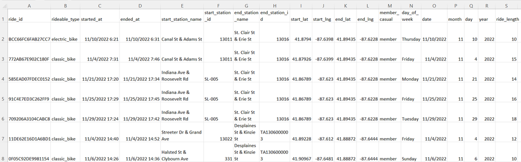

```r
knitr::include_graphics("all_rides_final.png")
```

### 4. Analyze

##### 4.1 Perform descriptive analysis

##### 4.1.1. Run a descriptive analysis on ride length.

This means that we need to know the mean,median, min and max values of ride length. All of these values can be obtained in one shot using the summary() function.

```r
summary(all_rides_final$ride_length)
```

```
##     Min.  1st Qu.   Median     Mean  3rd Qu.     Max.
##     1.00     6.00    10.00    16.15    18.00 12136.00
```

##### 4.1.2. Analyse how all these measures of ride length differ for casual and member riders

```r
#this calculates the overall average ride length for casual and member riders
aggregate(all_rides_final$ride_length ~ all_rides_final$member_casual, FUN = mean)
```

```
##   all_rides_final$member_casual all_rides_final$ride_length
## 1                        casual                    23.11608
## 2                        member                    12.27700
```

```r
#this calculates the minimum ride length for casual and member riders
aggregate(all_rides_final$ride_length ~ all_rides_final$member_casual, FUN = min)
```

```
##   all_rides_final$member_casual all_rides_final$ride_length
## 1                        casual                           1
## 2                        member                           1
```

```r
#this calculates the maximum ride length for casual and member riders
aggregate(all_rides_final$ride_length ~ all_rides_final$member_casual, FUN =max)
```

```
##   all_rides_final$member_casual all_rides_final$ride_length
## 1                        casual                       12136
## 2                        member                        1498
```

```r
# this calculates the median value of ride length for casual and member riders
aggregate(all_rides_final$ride_length ~ all_rides_final$member_casual, FUN = median)
```

```
##   all_rides_final$member_casual all_rides_final$ride_length
## 1                        casual                          13
## 2                        member                           9
```

##### 4.1.3. Look at the average ride length by day of the week for member vs casual riders

```r
aggregate(all_rides_final$ride_length ~ all_rides_final$member_casual + all_rides_final$day_of_week, FUN = mean)
```

```
##    all_rides_final$member_casual all_rides_final$day_of_week
## 1                         casual                      Friday
## 2                         member                      Friday
## 3                         casual                      Monday
## 4                         member                      Monday
## 5                         casual                    Saturday
## 6                         member                    Saturday
## 7                         casual                      Sunday
## 8                         member                      Sunday
## 9                         casual                    Thursday
## 10                        member                    Thursday
## 11                        casual                     Tuesday
## 12                        member                     Tuesday
## 13                        casual                   Wednesday
## 14                        member                   Wednesday
##    all_rides_final$ride_length
## 1                     22.56583
## 2                     12.22137
## 3                     22.69673
## 4                     11.67333
## 5                     26.16616
## 6                     13.73699
## 7                     26.79985
## 8                     13.77528
## 9                     20.27248
## 10                    11.76170
## 11                    20.60010
## 12                    11.78403
## 13                    19.76064
## 14                    11.74382
```

We can see that the days of the week are out of order. Let’s fix that

```r
all_rides_final$day_of_week <- ordered(all_rides_final$day_of_week, levels = c("Sunday", "Monday", "Tuesday", "Wednesday", "Thursday", "Friday", "Saturday"))
```

Now let’s run the code for the average ride length by day of the week for casual vs member riders

```r
aggregate(all_rides_final$ride_length ~ all_rides_final$member_casual + all_rides_final$day_of_week, FUN = mean)
```

```
##    all_rides_final$member_casual all_rides_final$day_of_week
## 1                         casual                      Sunday
## 2                         member                      Sunday
## 3                         casual                      Monday
## 4                         member                      Monday
## 5                         casual                     Tuesday
## 6                         member                     Tuesday
## 7                         casual                   Wednesday
## 8                         member                   Wednesday
## 9                         casual                    Thursday
## 10                        member                    Thursday
## 11                        casual                      Friday
## 12                        member                      Friday
## 13                        casual                    Saturday
## 14                        member                    Saturday
##    all_rides_final$ride_length
## 1                     26.79985
## 2                     13.77528
## 3                     22.69673
## 4                     11.67333
## 5                     20.60010
## 6                     11.78403
## 7                     19.76064
## 8                     11.74382
## 9                     20.27248
## 10                    11.76170
## 11                    22.56583
## 12                    12.22137
## 13                    26.16616
## 14                    13.73699
```

##### 4.1.4. Analyze ridership data by rider type and weekday

```r
all_rides_final %>%
  mutate(weekday = wday(started_at, label = TRUE)) %>% # creates weekday field using wday() function
  group_by(member_casual,weekday) %>% # groups by rider type and weekday
  summarise(number_of_rides = n(), average_duration = mean(ride_length)) %>% # calculates the number of rides and average duration
  arrange(member_casual,weekday) #  sorts
```

```
## # A tibble: 14 × 4
## # Groups:   member_casual [2]
##    member_casual weekday number_of_rides average_duration
##    <chr>         <ord>             <int>            <dbl>
##  1 casual        Sun              249451             26.8
##  2 casual        Mon              172936             22.7
##  3 casual        Tue              183727             20.6
##  4 casual        Wed              183016             19.8
##  5 casual        Thu              197807             20.3
##  6 casual        Fri              225048             22.6
##  7 casual        Sat              300407             26.2
##  8 member        Sun              295656             13.8
##  9 member        Mon              375762             11.7
## 10 member        Tue              447969             11.8
## 11 member        Wed              440735             11.7
## 12 member        Thu              436902             11.8
## 13 member        Fri              385404             12.2
## 14 member        Sat              333064             13.7
```

##### 4.1.5. Create a visualization that shows the number of rides by rider type throughout a week

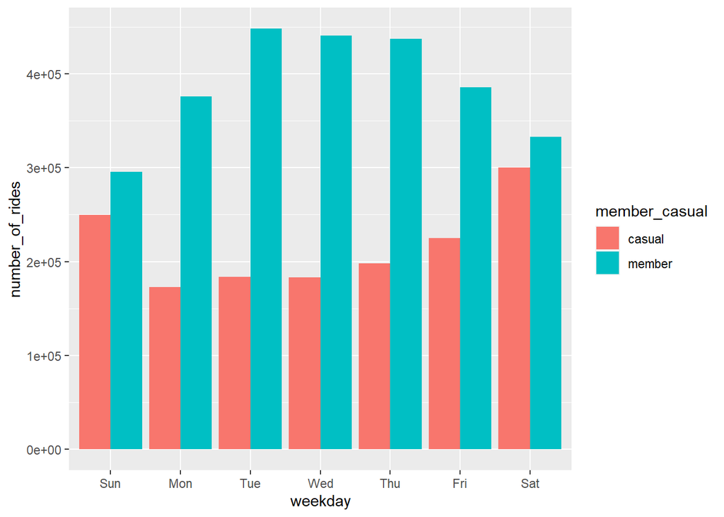

```r
all_rides_final %>%
  mutate(weekday = wday(started_at, label = TRUE)) %>%
  group_by(member_casual,weekday) %>%
  summarise(number_of_rides = n(), average_duration = mean(ride_length)) %>%
  arrange(member_casual,weekday) %>%
  ggplot(aes(x=weekday,y=number_of_rides,fill=member_casual)) + geom_col(position="dodge")
```

**The graph shows us that member riders ride more number of bikes than casual riders in a week**

##### 4.1.6. Create a visualization that shows the average ride length for each rider type throughout a week

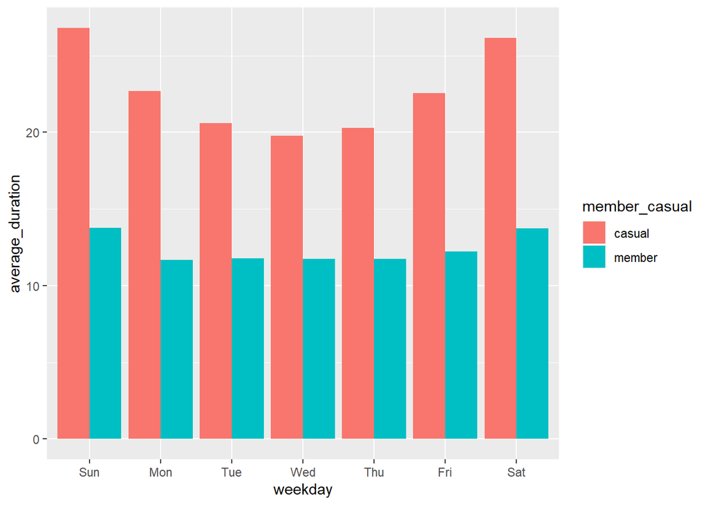

```r
all_rides_final %>%
  mutate(weekday = wday(started_at, label = TRUE)) %>%
  group_by(member_casual,weekday) %>%
  summarise(number_of_rides = n(), average_duration = mean(ride_length)) %>%
  arrange(member_casual,weekday) %>%
  ggplot(aes(x=weekday,y=average_duration,fill=member_casual)) + geom_col(position="dodge")
```

**This graph shows that though member riders ride more number of bikes, it is the casual riders that ride their bikes for a long time.**

### 5.Share

**Export the final file for further analysis**

I created a final csv file and exported it for further analysis and visualization using Tableau

```r
write.csv(all_rides_final, "C:\\Users\\susan\\OneDrive\\Documents\\Data analysis\\Module 8\\Case study_cyclistic\\Insights\\all_rides_export.csv", row.names=FALSE)
```